# Deploy and monitor a machine learning workflow for Image Classification

## Setting up this notebook

Notes about the instance size and kernel setup: this notebook has been tested on

1. The `Python 3 (Data Science)` kernel
2. The `ml.t3.medium` instance

## Data Staging

We'll use a sample dataset called CIFAR to simulate the challenges Scones Unlimited are facing in Image Classification. In order to start working with CIFAR we'll need to:

1. Extract the data from a hosting service
2. Transform it into a usable shape and format
3. Load it into a production system

In other words, we're going to do some simple ETL!

### 1. Extract the data from the hosting service

In the cell below, define a function `extract_cifar_data` that extracts python version of the CIFAR-100 dataset. The CIFAR dataaset is open source and generously hosted by the University of Toronto at: https://www.cs.toronto.edu/~kriz/cifar-100-python.tar.gz

```python
%pip install sagemaker
%pip install boto3
%pip install python-dotenv
```

```python
import requests

def extract_cifar_data(url, filename="cifar.tar.gz"):
    """A function for extracting the CIFAR-100 dataset and storing it as a gzipped file

    Arguments:
    url      -- the URL where the dataset is hosted
    filename -- the full path where the dataset will be written

    """

    # Todo: request the data from the data url
    # Hint: use `requests.get` method
    r = requests.get(url)
    with open(filename, "wb") as file_context:
        file_context.write(r.content)
    return
```

Let's test it out! Run the following cell and check whether a new file `cifar.tar.gz` is created in the file explorer.

```python
extract_cifar_data("https://www.cs.toronto.edu/~kriz/cifar-100-python.tar.gz")
```

### 2. Transform the data into a usable shape and format

Clearly, distributing the data as a gzipped archive makes sense for the hosting service! It saves on bandwidth, storage, and it's a widely-used archive format. In fact, it's so widely used that the Python community ships a utility for working with them, `tarfile`, as part of its Standard Library. Execute the following cell to decompress your extracted dataset:

```python
import tarfile

with tarfile.open("cifar.tar.gz", "r:gz") as tar:
    tar.extractall()
```

A new folder `cifar-100-python` should be created, containing `meta`, `test`, and `train` files. These files are `pickles` and the [CIFAR homepage](https://www.cs.toronto.edu/~kriz/cifar.html) provides a simple script that can be used to load them. We've adapted the script below for you to run:

```python
import pickle

with open("./cifar-100-python/meta", "rb") as f:
    dataset_meta = pickle.load(f, encoding='bytes')

with open("./cifar-100-python/test", "rb") as f:
    dataset_test = pickle.load(f, encoding='bytes')

with open("./cifar-100-python/train", "rb") as f:
    dataset_train = pickle.load(f, encoding='bytes')
```

```python
# Feel free to explore the datasets

dataset_train.keys()
```

```
dict_keys([b'filenames', b'batch_label', b'fine_labels', b'coarse_labels', b'data'])
```

```
b'bike_s_000658.png'
8
```

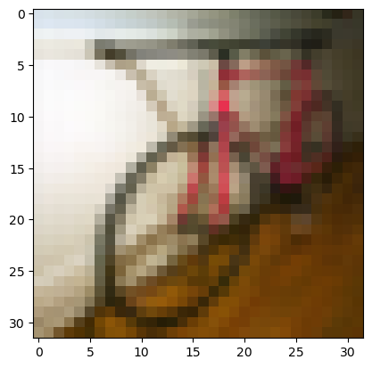

```python
i = 28
print(dataset_test[b'filenames'][i])
print(dataset_test[b'fine_labels'][i])
#print(dataset_test[b'batch_label'][i])
#print(dataset_test[b'coarse_labels'][i])
row = dataset_test[b'data'][i]
test_image = np.dstack((
    row[0:1024].reshape(32,32),
    row[1024:2048].reshape(32,32),
    row[2048:].reshape(32,32)
))
import matplotlib.pyplot as plt
plt.imshow(test_image);
```

```python
32*32*3
```

```
3072
```

For a simple gut-check, let's transform one of our images. Each 1024 items in a row is a channel (red, green, then blue). Each 32 items in the channel are a row in the 32x32 image. Using python, we can stack these channels into a 32x32x3 array, and save it as a PNG file:

```python
import numpy as np

# Each 1024 in a row is a channel (red, green, then blue)
row = dataset_train[b'data'][0]
red, green, blue = row[0:1024], row[1024:2048], row[2048:]

# Each 32 items in the channel are a row in the 32x32 image
red = red.reshape(32,32)
green = green.reshape(32,32)
blue = blue.reshape(32,32)

# Combine the channels into a 32x32x3 image!
combined = np.dstack((red,green,blue))
```

For a more concise version, consider the following:

```python
# All in one:
test_image = np.dstack((
    row[0:1024].reshape(32,32),
    row[1024:2048].reshape(32,32),
    row[2048:].reshape(32,32)
))
```

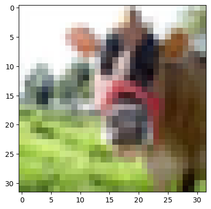

```python
import matplotlib.pyplot as plt
plt.imshow(test_image);
```

```python
test_image.shape
```

```
(32, 32, 3)
```

Looks like a cow! Let's check the label. `dataset_meta` contains label names in order, and `dataset_train` has a list of labels for each row.

```python
dataset_train[b'fine_labels'][0]
```

```
19
```

```python
dataset_meta[b'fine_label_names']
```

```
[b'apple',
 b'aquarium_fish',
 b'baby',
 b'bear',
 b'beaver',
 b'bed',
 b'bee',
 b'beetle',
 b'bicycle',
 b'bottle',
 b'bowl',
 b'boy',
 b'bridge',
 b'bus',
 b'butterfly',
 b'camel',
 b'can',
 b'castle',
 b'caterpillar',
 b'cattle',
 b'chair',
 b'chimpanzee',
 b'clock',
 b'cloud',
 b'cockroach',
 b'couch',
 b'crab',
 b'crocodile',
 b'cup',
 b'dinosaur',
 b'dolphin',
 b'elephant',
 b'flatfish',
 b'forest',
 b'fox',
 b'girl',
 b'hamster',
 b'house',
 b'kangaroo',
 b'keyboard',
```

[output cut: 45 more lines]

```
 b'tank',
 b'telephone',
 b'television',
 b'tiger',
 b'tractor',
 b'train',
 b'trout',
 b'tulip',
 b'turtle',
 b'wardrobe',
 b'whale',
 b'willow_tree',
 b'wolf',
 b'woman',
 b'worm']
```

Our image has a label of `19`, so let's see what the 19th item is in the list of label names.

```python
print(dataset_meta[b'fine_label_names'][19])
```

```
b'cattle'
```

Ok! 'cattle' sounds about right. By the way, using the previous two lines we can do:

```python
n = 0
print(dataset_meta[b'fine_label_names'][dataset_train[b'fine_labels'][n]])
```

```
b'cattle'
```

Now we know how to check labels, is there a way that we can also check file names? `dataset_train` also contains a `b'filenames'` key. Let's see what we have here:

```python
print(dataset_train[b'filenames'][0])
```

```
b'bos_taurus_s_000507.png'
```

"Taurus" is the name of a subspecies of cattle, so this looks like a pretty reasonable filename. To save an image we can also do:

```python
plt.imsave("file.png", test_image)
```

Your new PNG file should now appear in the file explorer -- go ahead and pop it open to see!

In the following cell, identify the label numbers for Bicycles and Motorcycles:

```python
import pandas as pd
from operator import indexOf

image_type_indexes = []
#print(dataset_meta[b'fine_label_names'])
# Todo: Filter the dataset_train and dataset_meta objects to find the label numbers for Bicycle and Motorcycles
bicycle_index = indexOf(dataset_meta[b'fine_label_names'], b'bicycle')
print('bicycle index', bicycle_index)
image_type_indexes.append(bicycle_index)

image_type_indexes.append(indexOf(dataset_meta[b'fine_label_names'], b'bus'))
image_type_indexes.append(indexOf(dataset_meta[b'fine_label_names'], b'lawn_mower'))
motorcycle_index = indexOf(dataset_meta[b'fine_label_names'], b'motorcycle')
print('motorcycle index', motorcycle_index)
image_type_indexes.append(motorcycle_index)
image_type_indexes.append(indexOf(dataset_meta[b'fine_label_names'], b'pickup_truck'))
image_type_indexes.append(indexOf(dataset_meta[b'fine_label_names'], b'streetcar'))
image_type_indexes.append(indexOf(dataset_meta[b'fine_label_names'], b'tank'))
image_type_indexes.append(indexOf(dataset_meta[b'fine_label_names'], b'tractor'))
image_type_indexes.append(indexOf(dataset_meta[b'fine_label_names'], b'train'))

print(image_type_indexes)
```

```
bicycle index 8
motorcycle index 48
[8, 13, 41, 48, 58, 81, 85, 89, 90]
```

```python
#df_train = pd.DataFrame({
#    "filenames": dataset_train[b'filenames'],
#    "labels": dataset_train[b'fine_labels'],
#    "row": range(len(dataset_train[b'filenames']))
#})
#df_train = df_train.loc[(df_train['labels'] == 8) | (df_train['labels'] == 48)]
#df_train.head()
```

[output not shown]

```python
l = ['a', 'b', 'c']
'd' in l
```

```
False
```

```python
#Construct the dataframe
df_train = pd.DataFrame({
    "filenames": dataset_train[b'filenames'],
    "labels": dataset_train[b'fine_labels'],
    "row": range(len(dataset_train[b'filenames']))
})

# Drop all rows from df_train where label is not 8 or 48
#df_train = df_train.loc[(df_train['labels'] == 8) | (df_train['labels'] == 48)]
df_train = df_train.loc[df_train['labels'].isin(image_type_indexes)]


# Decode df_train.filenames so they are regular strings
df_train["filenames"] = df_train["filenames"].apply(
    lambda x: x.decode("utf-8")
)


df_test = pd.DataFrame({
    "filenames": dataset_test[b'filenames'],
    "labels": dataset_test[b'fine_labels'],
    "row": range(len(dataset_test[b'filenames']))
})

# Drop all rows from df_test where label is not 8 or 48
# df_test = df_test.loc[(df_test['labels'] == 8) | (df_test['labels'] == 48)]
df_test = df_test.loc[df_test['labels'].isin(image_type_indexes)]

# Decode df_test.filenames so they are regular strings
df_test["filenames"] = df_test["filenames"].apply(
    lambda x: x.decode("utf-8")
)
```

Now that the data is filtered for just our classes, we can save all our images.

```python
!mkdir ./train
!mkdir ./test
```

In the previous sections we introduced you to several key snippets of code:

1. Grabbing the image data:

```
dataset_train[b'data'][0]
```

1. A simple idiom for stacking the image data into the right shape

```
import numpy as np
np.dstack((
    row[0:1024].reshape(32,32),
    row[1024:2048].reshape(32,32),
    row[2048:].reshape(32,32)
))
```

1. A simple `matplotlib` utility for saving images

```
plt.imsave(path+row['filenames'], target)
```

Compose these together into a function that saves all the images into the `./test` and `./train` directories. Use the comments in the body of the `save_images` function below to guide your construction of the function:

```python
## TODO: save ALL images using the save_images function


def save_images(row, path, dataset):
    #Grab the image data in row-major form
    #img = row[b'data']
    data_index =  row['row']
    img = dataset[b'data'][data_index]
    target = np.dstack((
        img[0:1024].reshape(32,32),
        img[1024:2048].reshape(32,32),
        img[2048:].reshape(32,32)
    ))
    plt.imsave(path+row['filenames'], target)
    # Return any signal data you want for debugging
    return

## TODO: save ALL images using the save_images function
for index, row in df_train.iterrows():
    save_images(row, './train/', dataset_train)


for index, row in df_test.iterrows():
    save_images(row, './test/', dataset_test)
```

### 3. Load the data

Now we can load the data into S3.

Using the sagemaker SDK grab the current region, execution role, and bucket.

```python
from dotenv import load_dotenv
import os
import sagemaker
import boto3
from sagemaker import get_execution_role

load_dotenv()
print(os.getenv('aws_secret_access_key'))

boto_session = boto3.Session(
    region_name='us-east-1',
    aws_access_key_id=os.getenv('aws_access_key_id'),
    aws_secret_access_key=os.getenv('aws_secret_access_key')
)

#smclient = boto3.Session(
#    aws_access_key_id=os.getenv('aws_access_key_id'),
#    aws_secret_access_key=os.getenv('aws_secret_access_key')
#).client('sagemaker')

sess = sagemaker.Session(boto_session=boto_session)

bucket = sess.default_bucket()                    # Set a default S3 bucket
print("Default Bucket: {}".format(bucket))

region = boto_session.region_name
print("AWS Region: {}".format(region))

#role = get_execution_role()
role = 'arn:aws:iam::379838984284:role/service-role/AmazonSageMaker-ExecutionRole-20211220T143633'
print("RoleArn: {}".format(role))
```

```
ek8zfa8JEVlnYZJmzihxwICE18Xz7bqLEe5tilgW
Default Bucket: sagemaker-us-east-1-379838984284
AWS Region: us-east-1
RoleArn: arn:aws:iam::379838984284:role/service-role/AmazonSageMaker-ExecutionRole-20211220T143633
```

With this data we can easily sync your data up into S3!

```python
import os

os.environ["DEFAULT_S3_BUCKET"] = bucket
!aws s3 sync ./train s3://${DEFAULT_S3_BUCKET}/train/
!aws s3 sync ./test s3://${DEFAULT_S3_BUCKET}/test/
```

[output not shown]

[output cut: 5345 more lines]

[output not shown]

And that's it! You can check the bucket and verify that the items were uploaded.

## Model Training

For Image Classification, Sagemaker [also expects metadata](https://docs.aws.amazon.com/sagemaker/latest/dg/image-classification.html) e.g. in the form of TSV files with labels and filepaths. We can generate these using our Pandas DataFrames from earlier:

```python
indexOf(image_type_indexes, df_train.iloc[3]['labels'])
```

```
5
```

```python
def to_metadata_file(df, prefix):
    df["s3_path"] = df["filenames"]
    #df["labels"] = df["labels"].apply(lambda x: 0 if x==8 else 1)
    df["labels"] = df["labels"].apply(lambda x: indexOf(image_type_indexes, x))
    return df[["row", "labels", "s3_path"]].to_csv(
        f"{prefix}.lst", sep="\t", index=False, header=False
    )

to_metadata_file(df_train.copy(), "train")
to_metadata_file(df_test.copy(), "test")
```

We can also upload our manifest files:

```python
import boto3

# Upload files
boto_session.resource('s3').Bucket(
    bucket).Object('train.lst').upload_file('./train.lst')
boto_session.resource('s3').Bucket(
    bucket).Object('test.lst').upload_file('./test.lst')
```

Using the `bucket` and `region` info we can get the latest prebuilt container to run our training job, and define an output location on our s3 bucket for the model. Use the `image_uris` function from the SageMaker SDK to retrieve the latest `image-classification` image below:

```python
# Use the image_uris function to retrieve the latest 'image-classification' image
from sagemaker.amazon.amazon_estimator import get_image_uri

print('region', boto_session.region_name)
algo_image = get_image_uri(boto_session.region_name, "image-classification")

s3_output_location = f"s3://{bucket}/models/image_model"
```

```
The method get_image_uri has been renamed in sagemaker>=2.
See: https://sagemaker.readthedocs.io/en/stable/v2.html for details.
Defaulting to the only supported framework/algorithm version: 1. Ignoring framework/algorithm version: 1.
```

```
region us-east-1
```

We're ready to create an estimator! Create an estimator `img_classifier_model` that uses one instance of `ml.p2.xlarge`. Ensure that y ou use the output location we defined above - we'll be referring to that later!

```python
img_classifier_model=sagemaker.estimator.Estimator(
    ## TODO: define your estimator options
    algo_image,
    role,
    instance_count=1,
    instance_type="ml.p2.xlarge",
   # volume_size=50,
   # max_run=360000,
    input_mode="File",
    output_path=s3_output_location,
    sagemaker_session=sess,
)
```

We can also set a few key hyperparameters and define the inputs for our model:

```python
img_classifier_model.set_hyperparameters(
    image_shape='3,32,32', # TODO: Fill in
    num_classes=len(image_type_indexes), # TODO: Fill in
    num_training_samples=len(df_train), # TODO: fill in
    epochs=100,
)
```

The `image-classification` image uses four input channels with very specific input parameters. For convenience, we've provided them below:

```python
from sagemaker.debugger import Rule, rule_configs
from sagemaker.session import TrainingInput
model_inputs = {
        "train": sagemaker.inputs.TrainingInput(
            s3_data=f"s3://{bucket}/train/",
            content_type="application/x-image"
        ),
        "validation": sagemaker.inputs.TrainingInput(
            s3_data=f"s3://{bucket}/test/",
            content_type="application/x-image"
        ),
        "train_lst": sagemaker.inputs.TrainingInput(
            s3_data=f"s3://{bucket}/train.lst",
            content_type="application/x-image"
        ),
        "validation_lst": sagemaker.inputs.TrainingInput(
            s3_data=f"s3://{bucket}/test.lst",
            content_type="application/x-image"
        )
}
```

Great, now we can train the model using the model_inputs. In the cell below, call the `fit` method on our model,:

```python
## TODO: train your model

img_classifier_model.fit(model_inputs, wait=True)
```

[output not shown]

[output cut: 58 more lines]

[output not shown]

[output not shown]

```python
# if loading an existing model
#model_data = 's3://sagemaker-us-east-1-379838984284/models/image_model/image-classification-2021-12-28-14-01-23-050/output/model.tar.gz'
model_data = 's3://sagemaker-us-east-1-379838984284/models/image_model/image-classification-2022-01-04-17-57-16-340/output/model.tar.gz'

img_classifier_model = sagemaker.model.Model(
    image_uri=algo_image,
    model_data=model_data,
    role=role,
    sagemaker_session=sess)

#model.deploy(
#   initial_instance_count=1,
#   instance_type="ml.m5.xlarge",
#)
```

### Getting ready to deploy

To begin with, let's configure Model Monitor to track our deployment. We'll define a `DataCaptureConfig` below:

```python
from sagemaker.model_monitor import DataCaptureConfig

data_capture_config = DataCaptureConfig(
    ## TODO: Set config options
    destination_s3_uri=f"s3://{bucket}/data_capture",
    enable_capture=True,
    sampling_percentage=100,
)
```

Note the `destination_s3_uri` parameter: At the end of the project, we can explore the `data_capture` directory in S3 to find crucial data about the inputs and outputs Model Monitor has observed on our model endpoint over time.

With that done, deploy your model on a single `ml.m5.xlarge` instance with the data capture config attached:

```python
from time import gmtime, strftime
endpoint_name = "udacity-workflow-project-model-monitor-" + strftime("%Y-%m-%d-%H-%M-%S", gmtime())

print("EndpointName={}".format(endpoint_name))


deployment = img_classifier_model.deploy(
    ## TODO: fill in deployment options
    initial_instance_count=1,
    instance_type="ml.m5.xlarge",
    endpoint_name=endpoint_name,
    data_capture_config=data_capture_config,
    )

#endpoint = deployment.endpoint_name
#print(endpoint)
```

```
EndpointName=udacity-workflow-project-model-monitor-2022-01-04-22-15-25
---------------!
```

Note the endpoint name for later as well.

Next, instantiate a Predictor:

```python
from sagemaker.predictor import Predictor
from sagemaker.serializers import CSVSerializer
import time

predictor = Predictor(endpoint_name=endpoint_name,
                      sagemaker_session=sess)
```

In the code snippet below we are going to prepare one of your saved images for prediction. Use the predictor to process the `payload`.

```python
from sagemaker.serializers import IdentitySerializer
import base64

predictor.serializer = IdentitySerializer("image/png")
#inference = ## TODO: Process the payload with your predictor
with open("./test/bicycle_s_001789.png", "rb") as f:
    payload = f.read()
    inference = predictor.predict(data=payload)
    time.sleep(1)
```

```python
print(inference)
```

```
b'[0.9952849745750427, 8.782553777564317e-05, 5.405864067142829e-05, 0.002637747908011079, 4.6181381208043604e-07, 0.0003848529595416039, 2.9934357371530496e-05, 0.0015152686974033713, 4.840591373067582e-06]'
```

### Draft Lambdas and Step Function Workflow

Your operations team uses Step Functions to orchestrate serverless workflows. One of the nice things about Step Functions is that [workflows can call other workflows](https://docs.aws.amazon.com/step-functions/latest/dg/connect-stepfunctions.html), so the team can easily plug your workflow into the broader production architecture for Scones Unlimited.

In this next stage you're going to write and deploy three Lambda functions, and then use the Step Functions visual editor to chain them together! Our functions are going to work with a simple data object:

```
{
    "inferences": [], # Output of predictor.predict
    "s3_key": "", # Source data S3 key
    "s3_bucket": "", # Source data S3 bucket
    "image_data": ""  # base64 encoded string containing the image data
}
```

A good test object that you can use for Lambda tests and Step Function executions, throughout the next section, might look like this:

```
{
  "image_data": "",
  "s3_bucket": MY_BUCKET_NAME, # Fill in with your bucket
  "s3_key": "test/bicycle_s_000513.png"
}
```

Using these fields, your functions can read and write the necessary data to execute your workflow. Let's start with the first function. Your first Lambda function will copy an object from S3, base64 encode it, and then return it to the step function as `image_data` in an event.

Go to the Lambda dashboard and create a new Lambda function with a descriptive name like "serializeImageData" and select thr 'Python 3.8' runtime. Add the same permissions as the SageMaker role you created earlier. (Reminder: you do this in the Configuration tab under "Permissions"). Once you're ready, use the starter code below to craft your Lambda handler:

[output not shown]

The next function is responsible for the classification part - we're going to take the image output from the previous function, decode it, and then pass inferences back to the the Step Function.

Because this Lambda will have runtime dependencies (i.e. the SageMaker SDK) you'll need to package them in your function. *Key reading:* https://docs.aws.amazon.com/lambda/latest/dg/python-package-create.html#python-package-create-with-dependency

Create a new Lambda function with the same rights and a descriptive name, then fill in the starter code below for your classifier Lambda.

[output not shown]

Finally, we need to filter low-confidence inferences. Define a threshold between 1.00 and 0.000 for your model: what is reasonble for you? If the model predicts at `.70` for it's highest confidence label, do we want to pass that inference along to downstream systems? Make one last Lambda function and tee up the same permissions:

[output not shown]

Once you have tested the lambda functions, save the code for each lambda function in a python script called 'lambda.py'.

With your lambdas in place, you can use the Step Functions visual editor to construct a workflow that chains them together. In the Step Functions console you'll have the option to author a Standard step function *Visually*.

When the visual editor opens, you'll have many options to add transitions in your workflow. We're going to keep it simple and have just one: to invoke Lambda functions. Add three of them chained together. For each one, you'll be able to select the Lambda functions you just created in the proper order, filter inputs and outputs, and give them descriptive names.

Make sure that you:

1. Are properly filtering the inputs and outputs of your invokations (e.g. `$.body`)
2. Take care to remove the error handling from the last function - it's supposed to "fail loudly" for your operations colleagues!

Take a screenshot of your working step function in action and export the step function as JSON for your submission package.

Great! Now you can use the files in `./test` as test files for our workflow. Depending on our threshold, our workflow should reliably pass predictions about images from `./test` on to downstream systems, while erroring out for inferences below our confidence threshold!

### Testing and Evaluation

Do several step function invokations using data from the `./test` folder. This process should give you confidence that the workflow both *succeeds* AND *fails* as expected. In addition, SageMaker Model Monitor will generate recordings of your data and inferences which we can visualize.

Here's a function that can help you generate test inputs for your invokations:

```python
import random
import boto3
import json


def generate_test_case():
    # Setup s3 in boto3
    s3 = boto3.resource('s3')

    # Randomly pick from sfn or test folders in our bucket
    objects = s3.Bucket(bucket).objects.filter(Prefix="test")

    # Grab any random object key from that folder!
    obj = random.choice([x.key for x in objects])

    return json.dumps({
        "endpoint": endpoint_name,
        "image_data": "",
        "s3_bucket": bucket,
        "s3_key": obj
    })
```

```python
# invoke step function with generated data
test_cases = []
num_tests = 200
for i in range(num_tests):
    test_cases.append(generate_test_case())

sf = boto_session.client('stepfunctions')

for i, test in enumerate(test_cases):
    # print('test', i, test)
    # run step function for each test
    sf.start_execution(stateMachineArn='arn:aws:states:us-east-1:379838984284:stateMachine:MyStateMachine',
                       #name='string',
                       input=json.dumps(test),
                       #traceHeader='string'
                       )
```

In the Step Function dashboard for your new function, you can create new executions and copy in the generated test cases. Do several executions so that you can generate data you can evaluate and visualize.

Once you've done several executions, let's visualize the record of our inferences. Pull in the JSONLines data from your inferences like so:

```python
from sagemaker.s3 import S3Downloader

# In S3 your data will be saved to a datetime-aware path
# Find a path related to a datetime you're interested in
# s3_uri = 's3://sagemaker-us-east-1-379838984284/data_capture/udacity-workflow-project-model-monitor-2022-01-02-14-46-26/AllTraffic/2022/01/02/14/57-14-391-9ec0c072-7a8f-4074-8cc4-8958d00ff0d3.jsonl'
#s3_uri = 's3://sagemaker-us-east-1-379838984284/data_capture/udacity-workflow-project-model-monitor-2022-01-03-17-04-42/AllTraffic/2022/01/03/17/16-50-246-bf816ed9-ad6b-4298-a853-f010b2719f8e.jsonl'
s3_uris = [
    's3://sagemaker-us-east-1-379838984284/data_capture/udacity-workflow-project-model-monitor-2022-01-04-22-15-25/AllTraffic/2022/01/04/22/30-32-635-8aae7b76-9933-4682-bcb9-fcdf3b759dbc.jsonl',
    's3://sagemaker-us-east-1-379838984284/data_capture/udacity-workflow-project-model-monitor-2022-01-04-22-15-25/AllTraffic/2022/01/04/22/23-44-053-62596edd-1fad-4f20-aa29-181e21c68fa0.jsonl'
]

for s3_uri in s3_uris:
    S3Downloader.download(s3_uri=s3_uri,
                          local_path='captured_data',
                          sagemaker_session=sess)

# Feel free to repeat this multiple times and pull in more data
```

The data are in JSONLines format, where multiple valid JSON objects are stacked on top of eachother in a single `jsonl` file. We'll import an open-source library, `jsonlines` that was purpose built for parsing this format.

```python
%pip install jsonlines
import jsonlines
```

Now we can extract the data from each of the source files:

```python
import os

# List the file names we downloaded
file_handles = os.listdir("./captured_data")

# Dump all the data into an array
json_data = []
for jsonl in file_handles:
    print(jsonl)
    with jsonlines.open(f"./captured_data/{jsonl}") as reader:
        for obj in reader:
#        data = f.read()
            #print('obj', obj)
            json_data.append(obj)
#print('keys ', json_data[0].keys())
#print('capture_data', json_data[0]['captureData']["endpointOutput"]["data"])
print('len', len(json_data))
```

```
30-32-635-8aae7b76-9933-4682-bcb9-fcdf3b759dbc.jsonl
23-44-053-62596edd-1fad-4f20-aa29-181e21c68fa0.jsonl
len 201
```

The data should now be a list of dictionaries, with significant nesting. We'll give you an example of some code that grabs data out of the objects and visualizes it:

```python
# Define how we'll get our data
def simple_getter(obj):
    inferences = obj["captureData"]["endpointOutput"]["data"]
    timestamp = obj["eventMetadata"]["inferenceTime"]
    return json.loads(inferences), timestamp

simple_getter(json_data[0])
```

```
([0.0023276584688574076,
  0.008464014157652855,
  0.0006348813185468316,
  0.015598743222653866,
  0.9363937973976135,
  0.0005288271349854767,
  0.0003484936023596674,
  0.03500998020172119,
  0.0006936451536603272],
 '2022-01-04T22:30:32Z')
```

Finally, here's an example of a visualization you can build with this data. In this last part, you will take some time and build your own - the captured data has the input images, the resulting inferences, and the timestamps.

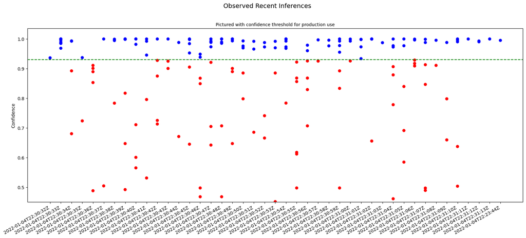

```python
# Populate the data for the x and y axis
x = []
y = []
y_argmax = []
for obj in json_data:
    inference, timestamp = simple_getter(obj)
    y.append(max(inference))
    y_argmax.append(np.argmax(inference))
    x.append(timestamp)

# Todo: here is an visualization example, take some time to build another visual that helps monitor the result
# Plot the data
plt.figure(figsize=(20,8))#setting the figure size

THRESHOLD = 0.93

plt.scatter(x, y, c=['r' if k<THRESHOLD else 'b' for k in y])
# horizontal line matches image threshold
plt.axhline(y=THRESHOLD, color='g', linestyle='--')
plt.ylim(bottom=.45)

# Add labels
plt.ylabel("Confidence")
plt.suptitle("Observed Recent Inferences", size=14)
plt.title("Pictured with confidence threshold for production use", size=10)

# Give it some pizzaz!
plt.style.use("Solarize_Light2")
plt.gcf().autofmt_xdate()
```

```
number of images with a low confidence classfication 102
```

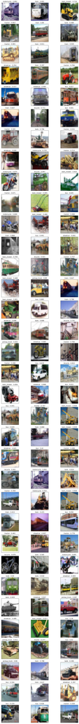

```python
import matplotlib.image as mpimg
import matplotlib as mpl

mpl.rcParams.update(mpl.rcParamsDefault)

# display low confident images - is there something in common
inferences = np.array(y)
low_confidence_count = np.sum(inferences < THRESHOLD)
print('number of images with a low confidence classfication', low_confidence_count)

(low_confidence_indexes,) = np.nonzero(inferences < THRESHOLD)
low_confidence_inferences = inferences[inferences < THRESHOLD]

image_count = len(low_confidence_inferences)
images_per_row = 3

row_count, col = divmod(image_count, images_per_row)
row_count = row_count + (col != 0)

fig, axs = plt.subplots(row_count, images_per_row, figsize=(12, 3 * row_count))

for i in range(image_count):
    low_confidence_index = low_confidence_indexes[i]
    imgstring = json_data[low_confidence_index]['captureData']['endpointInput']['data']
    inference, timestamp = simple_getter(json_data[low_confidence_index])
    imgdata = base64.b64decode(imgstring)
    filename = 'tmp.png'  # I assume you have a way of picking unique filenames
    with open(filename, 'wb') as f:
        f.write(imgdata)
    quotient, remainder = divmod(i, 3)
    image_type = dataset_meta[b'fine_label_names'][image_type_indexes[np.argmax(inference)]].decode("utf-8")
    axs[quotient, remainder].title.set_text(f'{image_type} : {round(max(inference), 3)}')
    axs[quotient, remainder].imshow(mpimg.imread(filename))
    axs[quotient, remainder].set_xticks([])
    axs[quotient, remainder].set_yticks([])
```

### Congratulations!

You've reached the end of the project. In this project you created an event-drivent ML workflow that can be incorporated into the Scones Unlimited production architecture. You used the SageMaker Estimator API to deploy your SageMaker Model and Endpoint, and you used AWS Lambda and Step Functions to orchestrate your ML workflow. Using SageMaker Model Monitor, you instrumented and observed your Endpoint, and at the end of the project you built a visualization to help stakeholders understand the performance of the Endpoint over time. If you're up for it, you can even go further with these stretch goals:

- Extend your workflow to incorporate more classes: the CIFAR dataset includes other vehicles that Scones Unlimited can identify with this model.
- Modify your event driven workflow: can you rewrite your Lambda functions so that the workflow can process multiple image inputs in parallel? Can the Step Function "fan out" to accomodate this new workflow?
- Consider the test data generator we provided for you. Can we use it to create a "dummy data" generator, to simulate a continuous stream of input data? Or a big paralell load of data?
- What if we want to get notified every time our step function errors out? Can we use the Step Functions visual editor in conjunction with a service like SNS to accomplish this? Try it out!